# Child Report 2: Descriptive Analysis

Weiwei Wu

2024-03-25

## README

This document serves as a summary report of the descriptive analysis outcomes, generated through the script `code/02_descriptive_analysis.R`:

- More descriptive analyses are performed to identify trends and relationships among the variables included in the Table 1.
- Input files: `data/derived_data/data_clean.rds`
- Output files: `outputs/descriptive_outcome_barplt.png`, `outputs/descriptive_countinuous_plt.png`, `outputs/descriptive_categorical_pieplt.png`, `outputs/descriptive_categorical_barplt.png`

Make command for `code/02_descriptive_analysis.R` outputs:

```
outputs/descriptive_outcome_barplt.png outputs/descriptive_countinuous_plt.png utputs/descriptive_categorical_pieplt.png outputs/descriptive_categorical_barplt.png: data/derived_data/data_clean.rds
  Rscript code/02_descriptive_analysis.R
```

## 2 Descriptive Analysis

##### Outcome Variable

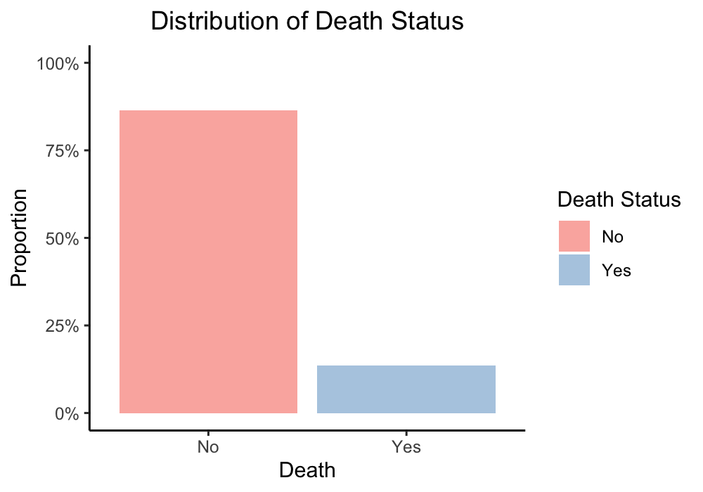

The figure below is the distribution of the outcome variable `Death Status`, which is imbalanced.

##### Continuous Variable

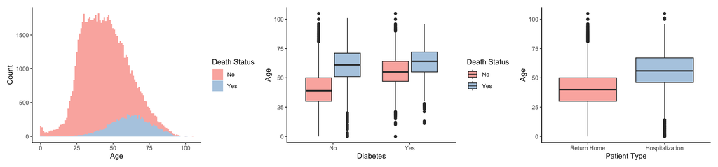

##### Categorical Variables

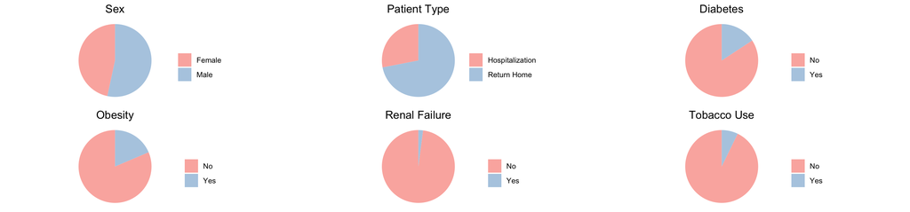

The pie charts above visualized categorical variables that included in the Table 1.

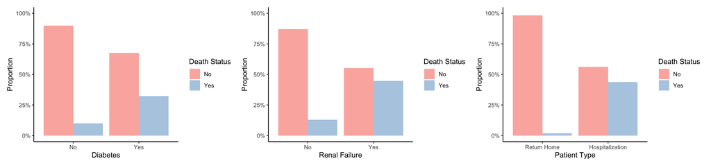

- Diabetes by Death Status (Bar Plot): atients without diabites have a lower death rate than those with renal failure.
- Renal Failure by Death Status (Bar Plot): Patients without renal failure have a lower death rate than those with renal failure.
- Patient Type by Death Status (Bar Plot): The returning home patients have a evidently lower death rate than those with hospitalized patients.